# SL exploration on PROLOGUE data

@CorradoLanera

2019-02-02

## Setup

Prima di tutto carichiamo i pacchetti necessari

```r
library(select)

library(SuperLearner)
library(Hmisc)
library(depigner)
library(DT)
library(pander)
    panderOptions("table.split.table", Inf)


library(tidyverse)
library(here)
```

A questo punto possiamo caricare i dati e sistemarli come ci è utile per le analisi che dovremo fare.

In particolare i predittori saranno: - Age, years - Sex - Body mass index, kg/m2 - Hypertension (history of) - Dyslipidemia (history of) - Adiponectin - Myocardial infarction - Percutaneous coronary intervention - Coronary artery bypass grafting - Chronic heart failure - Arrhythmia - Stroke - Systolic blood pressure, mm Hg - Diastolic blood pressure, mm Hg - HbA1c, percent - Fasting plasma glucose (FPG), mmol/l - Low-density lipoprotein cholesterol (LDL), mmol/l - Serum creatinine, μmol/l

Mentre la variabile di risposta sarà: - delta HbA1c a 12 mesi

dicotomizzata secondo due scenari (success vs failure): 1. <= -1 vs > -1 2. <= -0.5 vs > -0.5

limitatamente all’arm sitagliptin)

```r
data("prologue")

used_data <- prologue %>%
    mutate(
        bmi = body_weight_0m / (height_background / 100)^2
    ) %>%
    filter(allocation == "sitagliptin") %>%
    mutate(delta_hba1c = hba1c_ngsp_12m - hba1c_ngsp_0m) %>%
    select(
        age, sex, bmi,
        history_hypertension, history_dyslipidemia,
        hmw_adiponectin_0m, history_myocardial_infarction,
        history_pci, history_cabg, history_cardiac_insufficiency,
        history_arrhythmia, ev_stroke, sbp_0m, dbp_0m, hba1c_ngsp_0m,
        fbs_0m, small_dense_ldl_0m, creatinine_0m,

        delta_hba1c
    ) %>%
    filter(!is.na(delta_hba1c))


scenario_1 <- used_data %>%
    mutate(
        delta_hba1c_1 = factor(delta_hba1c > -1,
            levels = c(TRUE, FALSE),
            labels = c("HbA1c > -1", "HbA1c <= -1")
        )
    ) %>%
    select(-delta_hba1c)

scenario_05 <- used_data %>%
    mutate(
        delta_hba1c_05 = factor(delta_hba1c > -0.5,
            levels = c(TRUE, FALSE),
            labels = c("HbA1c > -0.5", "HbA1c <= -0.5")
        )
    ) %>%
    select(-delta_hba1c)
```

A questo punto diamo uno sguardo ai dati e alle loro correlazioni

### Scenario delta-HbA1c 0 VS 12 mesi con cut-off a -1

```r
datatable(scenario_1)
```

|  | age | sex | bmi | history_hypertension | history_dyslipidemia | hmw_adiponectin_0m | history_myocardial_infarction | history_pci | history_cabg | history_cardiac_insufficiency | history_arrhythmia | ev_stroke | sbp_0m | dbp_0m | hba1c_ngsp_0m | fbs_0m | small_dense_ldl_0m | creatinine_0m | delta_hba1c_1 |
| --- | --- | --- | --- | --- | --- | --- | --- | --- | --- | --- | --- | --- | --- | --- | --- | --- | --- | --- | --- |
| 1 | 51 | male | 25.9697567389875 | True | True | 0.34 | False | False | False | True | True |  | 126 | 84 | 7.4 | 251 | 38.5 | 0.7 | HbA1c &gt; -1 |
| 2 | 72 | male | 21.4885442385389 | True | True | 5.01 | False | False | False | True | True |  | 128 | 60 | 7.3 | 131 | 18.1 | 1.21 | HbA1c &gt; -1 |
| 3 | 57 | male | 26.2053570896807 | True | True | 2.15 | False | False | False | True | False |  | 148 | 90 | 6.9 | 162 | 28.4 | 1.02 | HbA1c &gt; -1 |
| 4 | 65 | male | 25.0743900019837 | False | True |  | True | True | False | False | False |  | 135 | 88 | 6.2 | 113 |  | 0.85 | HbA1c &gt; -1 |
| 5 | 65 | female | 20.787653904537 | True | True |  | False | True | False | False | False |  | 146 | 70 | 6.3 | 83 |  | 0.61 | HbA1c &gt; -1 |
| 6 | 65 | female | 20.787653904537 | True | True |  | False | True | False | False | False |  | 146 | 70 | 6.3 | 83 |  | 0.61 | HbA1c &gt; -1 |
| 7 | 65 | female | 20.787653904537 | True | True |  | False | True | False | False | False |  | 146 | 70 | 6.3 | 83 |  | 0.61 | HbA1c &gt; -1 |
| 8 | 78 | male | 26.0655800428528 | True | True | 0.47 | False | True | True | False | False |  | 134 | 76 | 6.9 | 171 | 64.8 | 0.91 | HbA1c &gt; -1 |
| 9 | 75 | male | 26.6727632982777 | True | False | 0.74 | False | True | False | False | False |  | 107 | 61 | 6.8 | 104 | 36.8 | 1.3 | HbA1c &gt; -1 |
| 10 | 72 | male | 23.7252861602497 | True | True | 1.02 | True | True | False | False | False |  | 138 | 74 | 7.2 | 98 | 40 | 0.97 | HbA1c &gt; -1 |

[output cut: 193 more lines]

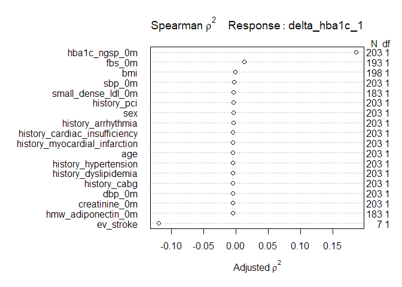

```r
spearman2(delta_hba1c_1 ~ .,
    data = mutate_all(scenario_1, as.numeric)
) %>%
 plot()
```

```r
summary(delta_hba1c_1 ~ .,
    data       = scenario_1,
    method     = "reverse",
    continuous = 3,
    test       = TRUE
) %>%
    tidy_summary(
        prtest = "P",
        exclude1 = FALSE, long = TRUE,
        digits = 3
    ) %>%
    pander()
```

|  | N | HbA1c > -1 (N=180) | HbA1c <= -1 (N=23) | P-value |
| --- | --- | --- | --- | --- |
| age | 203 | 64.0/69.5/75.0 | 60.0/72.0/79.5 | 0.724 |
| sex | 203 |  |  | 0.657 |
| male |  | 66% (118) | 61% ( 14) |  |
| female |  | 34% ( 62) | 39% ( 9) |  |
| bmi | 198 | 22.4/24.9/26.9 | 23.1/24.9/28.2 | 0.356 |
| history_hypertension | 203 |  |  | 0.862 |
| FALSE |  | 19% ( 34) | 17% ( 4) |  |
| TRUE |  | 81% (146) | 83% ( 19) |  |
| history_dyslipidemia | 203 |  |  | 0.864 |
| FALSE |  | 28% ( 50) | 26% ( 6) |  |
| TRUE |  | 72% (130) | 74% ( 17) |  |
| hmw_adiponectin_0m | 183 | 2.04/3.61/5.42 | 2.05/3.51/4.12 | 0.773 |
| history_myocardial_infarction | 203 |  |  | 0.722 |
| FALSE |  | 79% (143) | 83% ( 19) |  |
| TRUE |  | 21% ( 37) | 17% ( 4) |  |
| history_pci | 203 |  |  | 0.651 |
| FALSE |  | 74% (133) | 78% ( 18) |  |
| TRUE |  | 26% ( 47) | 22% ( 5) |  |
| history_cabg | 203 |  |  | 0.908 |
| FALSE |  | 91% (163) | 91% ( 21) |  |
| TRUE |  | 9% ( 17) | 9% ( 2) |  |
| history_cardiac_insufficiency | 203 |  |  | 0.718 |
| FALSE |  | 93% (168) | 91% ( 21) |  |
| TRUE |  | 7% ( 12) | 9% ( 2) |  |
| history_arrhythmia | 203 |  |  | 0.708 |
| FALSE |  | 86% (154) | 83% ( 19) |  |
| TRUE |  | 14% ( 26) | 17% ( 4) |  |
| ev_stroke | 7 |  |  | 0.495 |
| FALSE |  | 80% (4) | 100% (2) |  |
| TRUE |  | 20% (1) | 0% (0) |  |
| sbp_0m | 203 | 121/130/140 | 124/132/142 | 0.559 |
| dbp_0m | 203 | 67.2/73.5/80.0 | 68.0/73.0/78.0 | 0.958 |
| hba1c_ngsp_0m | 203 | 6.50/6.70/7.10 | 7.20/7.60/7.95 | <0.001 |
| fbs_0m | 193 | 110/125/151 | 123/156/178 | 0.064 |
| small_dense_ldl_0m | 183 | 21.0/30.0/44.7 | 20.6/24.0/49.9 | 0.553 |
| creatinine_0m | 203 | 0.690/0.800/0.980 | 0.765/0.810/0.895 | 0.994 |

Notiamo che in questo caso l’unica variabile significativamente diversa tra i due gruppi di outcome è proprio il valore baseline del valore della risposta, il quale potrebbe quindi diventare un predittore piuttosto importante. ### Scenario delta-HbA1c 0 VS 12 mesi con cut-off a -0.5

```r
datatable(scenario_05)
```

|  | age | sex | bmi | history_hypertension | history_dyslipidemia | hmw_adiponectin_0m | history_myocardial_infarction | history_pci | history_cabg | history_cardiac_insufficiency | history_arrhythmia | ev_stroke | sbp_0m | dbp_0m | hba1c_ngsp_0m | fbs_0m | small_dense_ldl_0m | creatinine_0m | delta_hba1c_05 |
| --- | --- | --- | --- | --- | --- | --- | --- | --- | --- | --- | --- | --- | --- | --- | --- | --- | --- | --- | --- |
| 1 | 51 | male | 25.9697567389875 | True | True | 0.34 | False | False | False | True | True |  | 126 | 84 | 7.4 | 251 | 38.5 | 0.7 | HbA1c &gt; -0.5 |
| 2 | 72 | male | 21.4885442385389 | True | True | 5.01 | False | False | False | True | True |  | 128 | 60 | 7.3 | 131 | 18.1 | 1.21 | HbA1c &gt; -0.5 |
| 3 | 57 | male | 26.2053570896807 | True | True | 2.15 | False | False | False | True | False |  | 148 | 90 | 6.9 | 162 | 28.4 | 1.02 | HbA1c &lt;= -0.5 |
| 4 | 65 | male | 25.0743900019837 | False | True |  | True | True | False | False | False |  | 135 | 88 | 6.2 | 113 |  | 0.85 | HbA1c &gt; -0.5 |
| 5 | 65 | female | 20.787653904537 | True | True |  | False | True | False | False | False |  | 146 | 70 | 6.3 | 83 |  | 0.61 | HbA1c &gt; -0.5 |
| 6 | 65 | female | 20.787653904537 | True | True |  | False | True | False | False | False |  | 146 | 70 | 6.3 | 83 |  | 0.61 | HbA1c &gt; -0.5 |
| 7 | 65 | female | 20.787653904537 | True | True |  | False | True | False | False | False |  | 146 | 70 | 6.3 | 83 |  | 0.61 | HbA1c &gt; -0.5 |
| 8 | 78 | male | 26.0655800428528 | True | True | 0.47 | False | True | True | False | False |  | 134 | 76 | 6.9 | 171 | 64.8 | 0.91 | HbA1c &gt; -0.5 |
| 9 | 75 | male | 26.6727632982777 | True | False | 0.74 | False | True | False | False | False |  | 107 | 61 | 6.8 | 104 | 36.8 | 1.3 | HbA1c &gt; -0.5 |
| 10 | 72 | male | 23.7252861602497 | True | True | 1.02 | True | True | False | False | False |  | 138 | 74 | 7.2 | 98 | 40 | 0.97 | HbA1c &lt;= -0.5 |

[output cut: 193 more lines]

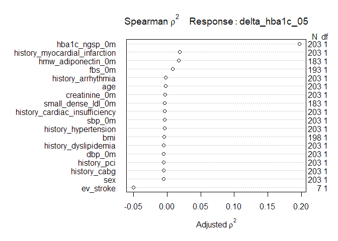

```r
spearman2(delta_hba1c_05 ~ .,
    data = mutate_all(scenario_05, as.numeric)
) %>%
 plot()
```

```r
summary(delta_hba1c_05 ~ .,
    data       = scenario_05,
    method     = "reverse",
    continuous = 3,
    test       = TRUE
) %>%
    tidy_summary(
        prtest = "P",
        exclude1 = FALSE, long = TRUE,
        digits = 3
    ) %>%
    pander()
```

|  | N | HbA1c > -0.5 (N=115) | HbA1c <= -0.5 (N=88) | P-value |
| --- | --- | --- | --- | --- |
| age | 203 | 63.5/70.0/75.5 | 64.0/69.5/76.2 | 0.46 |
| sex | 203 |  |  | 0.948 |
| male |  | 65% (75) | 65% (57) |  |
| female |  | 35% (40) | 35% (31) |  |
| bmi | 198 | 22.4/25.1/27.8 | 22.7/24.8/26.7 | 0.688 |
| history_hypertension | 203 |  |  | 0.579 |
| FALSE |  | 17% (20) | 20% (18) |  |
| TRUE |  | 83% (95) | 80% (70) |  |
| history_dyslipidemia | 203 |  |  | 0.819 |
| FALSE |  | 27% (31) | 28% (25) |  |
| TRUE |  | 73% (84) | 72% (63) |  |
| hmw_adiponectin_0m | 183 | 2.29/3.83/5.70 | 1.85/3.18/4.45 | 0.042 |
| history_myocardial_infarction | 203 |  |  | 0.028 |
| FALSE |  | 85% (98) | 73% (64) |  |
| TRUE |  | 15% (17) | 27% (24) |  |
| history_pci | 203 |  |  | 0.882 |
| FALSE |  | 75% (86) | 74% (65) |  |
| TRUE |  | 25% (29) | 26% (23) |  |
| history_cabg | 203 |  |  | 0.908 |
| FALSE |  | 90% (104) | 91% ( 80) |  |
| TRUE |  | 10% ( 11) | 9% ( 8) |  |
| history_cardiac_insufficiency | 203 |  |  | 0.55 |
| FALSE |  | 92% (106) | 94% ( 83) |  |
| TRUE |  | 8% ( 9) | 6% ( 5) |  |
| history_arrhythmia | 203 |  |  | 0.426 |
| FALSE |  | 87% (100) | 83% ( 73) |  |
| TRUE |  | 13% ( 15) | 17% ( 15) |  |
| ev_stroke | 7 |  |  | 0.35 |
| FALSE |  | 100% (3) | 75% (3) |  |
| TRUE |  | 0% (0) | 25% (1) |  |
| sbp_0m | 203 | 122/130/138 | 120/132/142 | 0.572 |
| dbp_0m | 203 | 68.0/74.0/80.0 | 67.5/72.0/80.0 | 0.83 |
| hba1c_ngsp_0m | 203 | 6.40/6.60/6.90 | 6.77/7.10/7.50 | <0.001 |
| fbs_0m | 193 | 110/124/143 | 110/137/158 | 0.108 |
| small_dense_ldl_0m | 183 | 20.4/29.5/45.4 | 21.4/31.2/45.0 | 0.506 |
| creatinine_0m | 203 | 0.680/0.800/0.950 | 0.700/0.810/0.973 | 0.534 |